# Analysis of Video Game Sales

BF

2025-08-26

## Question One

The graph shows the number of sales(in millions) per year.

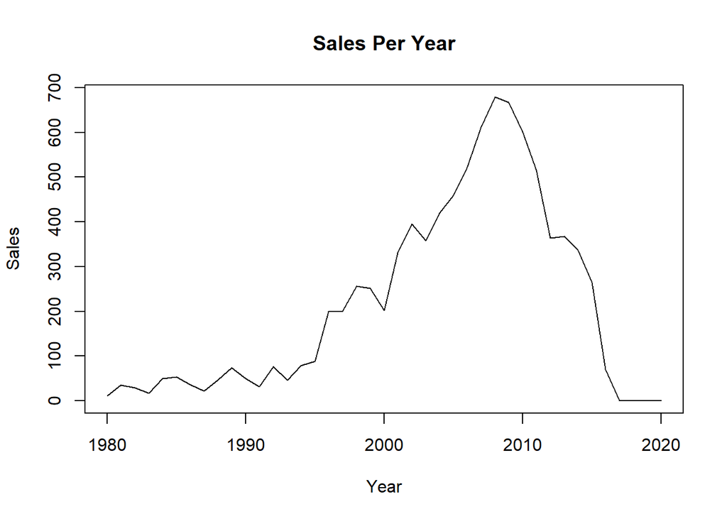

```r
#load CSV
mydata <- read.csv('vgsales.csv')

#Do my basic Data aggregating
sales <- aggregate(mydata$Global_Sales ~ mydata$Year, data = mydata, sum)
names(sales) <- c('Year', 'Sales')

#plotting
plot(sales$Year, sales$Sales,
     type = 'l',
     xlab = 'Year',
     ylab = 'Sales',
     main = 'Sales Per Year')
```

## Question Two

One of my hypotheses was that North America typically buys more video games than any other region, whether due to population or just general consumer tastes. The results of my data support this hypothesis since for most years North America has a higher average quantity purchase amount.

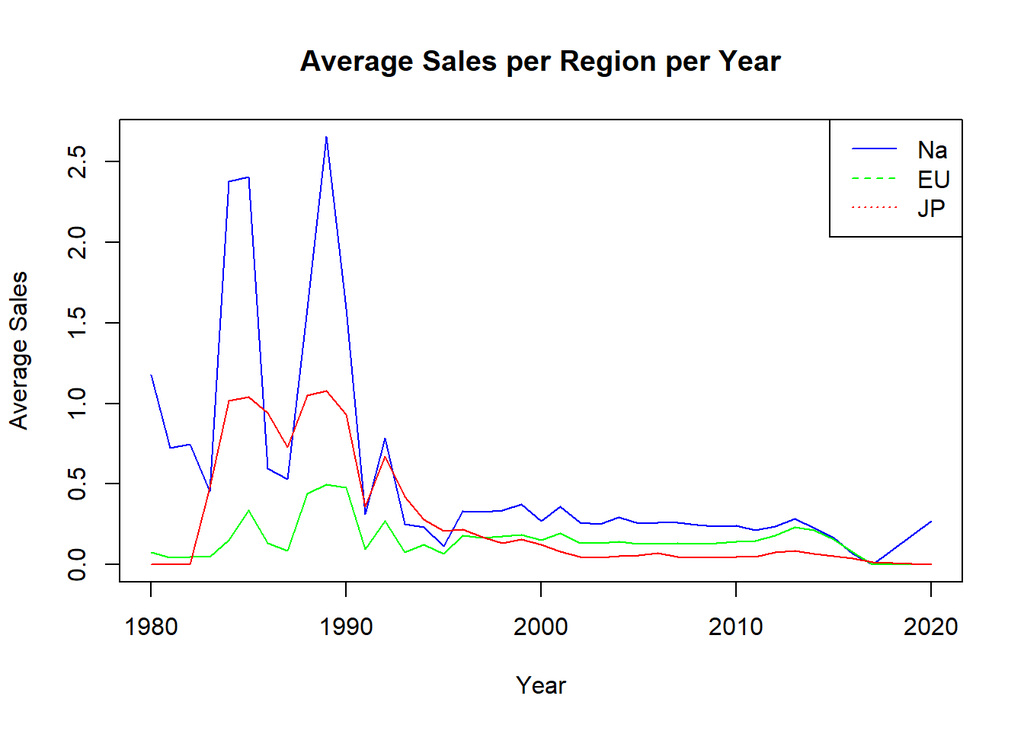

```r
#Set up data for the different regions
NaSales <- aggregate(mydata$NA_Sales ~ mydata$Year, data = mydata, mean)
names(NaSales) <- c('Year', 'NASales')
EuSales <- aggregate(mydata$EU_Sales ~ mydata$Year, data = mydata, mean)
names(EuSales) <- c('Year', 'EUSales')
JpSales <- aggregate(mydata$JP_Sales ~ mydata$Year, data = mydata, mean)
names(JpSales) <- c('Year', 'JPSales')

#plotting
plot(NaSales$Year, NaSales$NASales,
     col = 'blue',
     type = 'l',
     xlab = 'Year',
     ylab = 'Average Sales',
     main = 'Average Sales per Region per Year')
lines(EuSales$Year, EuSales$EUSales,
      col = 'green',
      type = 'l')
lines(JpSales$Year, JpSales$JPSales,
      col = 'red',
      type = 'l')
legend("topright",
       legend = c("Na", "EU", "JP"),
       col = c("blue", "green", "red"),
       lty = c(1, 2, 3))
```

## Question Three

One of my other hypotheses was that video game sales are trending upward, as in more sales are happening every year. What I learned from question one was that this data set does not have a lot of representation of video games released after about 2010. Therefore I filtered the data down to just games released prior to 2010 and then did my correlation testing on that. What I found was that there is very likely a positive correlation between year and sales, meaning my hypothesis is probably true.

```r
#Filtering data based on first question
filtered_data <- mydata[mydata$Year <= 2010, ]

#was getting non-numeric error so fixing
filtered_data$Year <- as.numeric(as.character(filtered_data$Year))
filtered_data$Global_Sales <- as.numeric(as.character(filtered_data$Global_Sales))

#aggregating the data
filtered_sales <- aggregate(filtered_data$Global_Sales ~ filtered_data$Year, data = mydata, sum)
names(filtered_sales) <- c('Year', 'Sales')


#Correlation testing
correlation <- cor.test(filtered_sales$Year, filtered_sales$Sales)
print(correlation)
```

```
##
##  Pearson's product-moment correlation
##
## data:  filtered_sales$Year and filtered_sales$Sales
## t = 12.716, df = 29, p-value = 2.19e-13
## alternative hypothesis: true correlation is not equal to 0
## 95 percent confidence interval:
##  0.8408402 0.9614568
## sample estimates:
##       cor
## 0.9208262
```

```r
#creating linear model to get direction of correlation
LinearModel <- lm(filtered_sales$Sales ~ filtered_sales$Year, data = mydata)
summary(LinearModel)
```

```
##
## Call:
## lm(formula = filtered_sales$Sales ~ filtered_sales$Year, data = mydata)
##
## Residuals:
##     Min      1Q  Median      3Q     Max
## -134.47  -61.12  -15.53   57.72  166.86
##
## Coefficients:
##                       Estimate Std. Error t value Pr(>|t|)
## (Intercept)         -44198.935   3493.461  -12.65 2.48e-13 ***
## filtered_sales$Year     22.266      1.751   12.72 2.19e-13 ***
## ---
## Signif. codes:  0 '***' 0.001 '**' 0.01 '*' 0.05 '.' 0.1 ' ' 1
##
## Residual standard error: 87.2 on 29 degrees of freedom
## Multiple R-squared:  0.8479, Adjusted R-squared:  0.8427
## F-statistic: 161.7 on 1 and 29 DF,  p-value: 2.19e-13
```

## Question Four

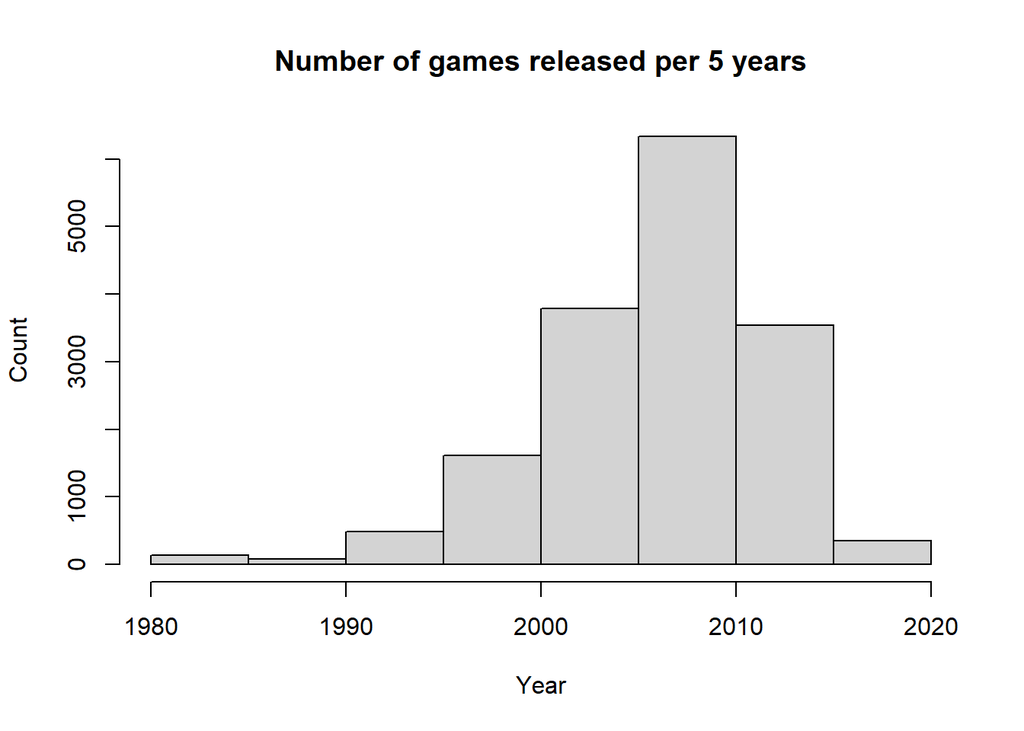

```r
#non-numeric error
mydata$Year <- as.numeric(as.character(mydata$Year))

#plotting
hist(mydata$Year,
     breaks = 8,
     xlab = 'Year',
     ylab = 'Count',
     main = 'Number of games released per 5 years')
```

## Question Five

I will be using the sales data per region that I found in question two. As you can see in the p value result, there is a statisically significant difference between the sales in North America and the sales in EU, meaning that my hypothesis is supported by the t-test.

```r
#Getting non-numeric error again
NaSales$NASales <- as.numeric(as.character(NaSales$NASales))
EuSales$EUSales <- as.numeric(as.character(EuSales$EUSales))

#running t-test
t_test_results <- t.test(NaSales$NASales, y = EuSales$EUSales)
print(t_test_results)
```

```
##
##  Welch Two Sample t-test
##
## data:  NaSales$NASales and EuSales$EUSales
## t = 3.8613, df = 41.289, p-value = 0.0003899
## alternative hypothesis: true difference in means is not equal to 0
## 95 percent confidence interval:
##  0.1932951 0.6170175
## sample estimates:
## mean of x mean of y
## 0.5634959 0.1583396
```